# Tabular + Images Example deepregression

# Simulating Data

We will use the MNIST data set as a source for the image part and generate additional tabular feature. First we load MNIST

```r
library(dplyr)
library(readr)
library(tensorflow)
library(RcppCNPy)

# load data
mnist <- tf$keras$datasets$mnist$load_data()
names(mnist) <- c("train", "test")
names(mnist$train) <- names(mnist$test) <- c("x", "y")

# convert to 0-1 range
mnist$train$x <- mnist$train$x / 255
# mnist$test$x <- mnist$test$x / 255

# reduce #samples
train_subset <- sample(1:dim(mnist$train$x)[1], 8000)
mnist$train$x <- mnist$train$x[train_subset,,]
mnist$train$y <- mnist$train$y[train_subset]
# test_subset <- sample(1:dim(mnist$test$x)[1], 4000)
# mnist$test$x <- mnist$test$x[test_subset,,]
# mnist$test$y <- mnist$test$y[test_subset]
```

We will go with a simple deep neural network for the unstructured part and see if that yields sufficient precision to fit the MNIST images:

```r
# define deep model
my_simple_dnn <- function(x) x %>%
  layer_flatten(input_shape = c(28, 28)) %>%
  layer_dense(units = 128, activation = 'relu') %>%
  layer_dense(units = 1, activation = 'linear')
```

Let’s now simulate data where the actual response is determined via structured effects of tabular data and a linear effect of the MNIST number:

$$y = sin(x_1) - 3x_2 + x_3^4 + 3\cdot\mbox{number} + \varepsilon, \varepsilon \sim \mathcal{N}(0,\sigma^2)$$

```r
# simulate data
set.seed(42)
x1 <- runif(NROW(mnist$train$y), min = -pi, max = pi)
x2 <- rnorm(NROW(mnist$train$y))
x3 <- rnorm(NROW(mnist$train$y))
y_gen <- sin(x1) - 3*x2 + x3^4 + 3*as.numeric(mnist$train$y)
y_gen <- y_gen - mean(y_gen) + rnorm(NROW(mnist$train$y))
data <- list(numbers = mnist$train$x, x1=x1, x2=x2, x3=x3)
```

# Training

Note that we won’t tell the model the number of the MNIST picture, but instead feed the original image into to check whether the model can learn a latent effect representing the number.

The variance we do not define using features, so this is a standard mean regression model. We therefore only have to define one formula. The corresponding deepregression call is

```r
devtools::load_all("~/deepregression_master/deepregression/R")
```

```
## Loading deepregression
```

```r
model <- deepregression(y = y_gen,
                        list_of_formulae = list(~ -1 + s(x1) + x2 + dnn(numbers) + s(x3),
                                                ~ 1),
                        list_of_deep_models = list(dnn = my_simple_dnn),
                        family = "normal",
                        data = data,
                        optimizer = optimizer_rmsprop(lr = 0.0001),
                        df = 9.6,
                        tf_seed = 42
                        )
```

```
## Set session seed to 42 (disabled GPU, CPU parallelism)
```

```
## Preparing additive formula(e)... Done.
## Translating data into tensors... Done.
```

```r
model %>% fit(epochs = 1000, early_stopping = TRUE, patience = 10, verbose = FALSE)
```

# Model Diagnostics

Finally, we check the model’s non-linear estimates, the structured coefficients and can also check what latent effect the model has learned. We start with the nonlinear effects (sinus and to the power of 4 effect):

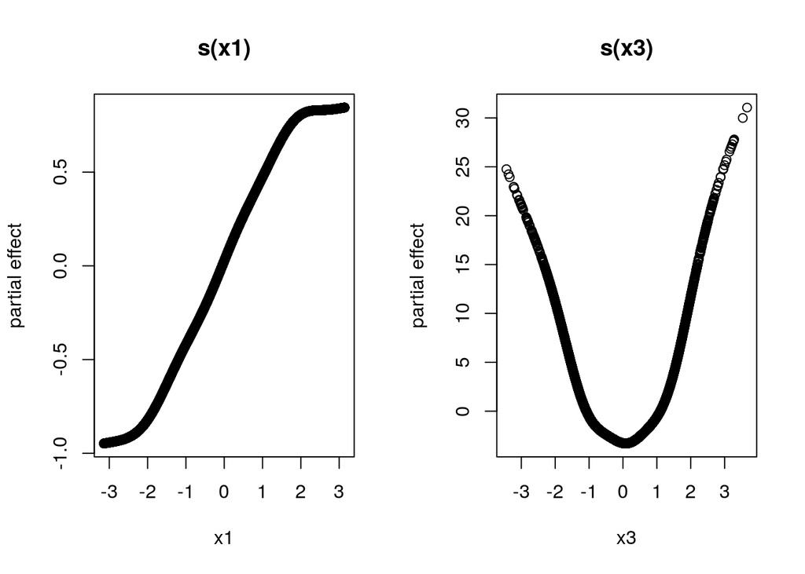

```r
par(mfrow=c(1,2))
plot(model)
```

Looks okayish. The structured coefficients (-3 and 1):

```r
# liner effect
coef(model)[[1]][[1]][1,1]
```

```
## [1] -2.3899
```

```r
# variance
coef(model)[[2]]
```

```
## $structured_linear
##          [,1]
## [1,] 1.693551
```

Seem to be shrinked versions of the original effect, but not too far off. Finally we check the latent representation:

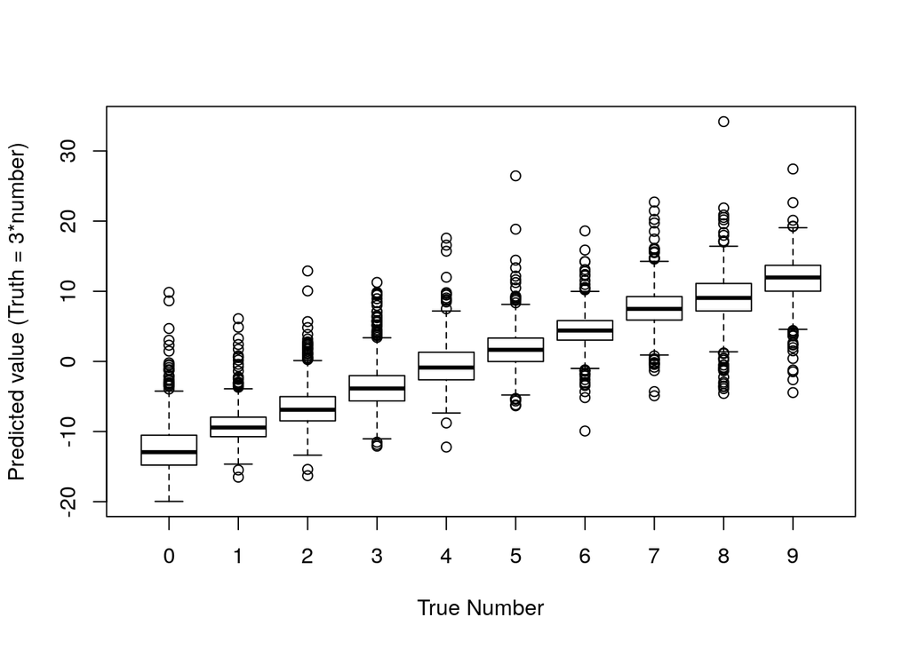

```r
pd <- data
pd$x1 <- pd$x2 <- pd$x3 <- rep(0,NROW(y_gen))
pr <- model %>% predict(pd)
par(mfrow=c(1,1))
boxplot(pr[,1] ~ mnist$train$y, xlab = "True Number", ylab = "Predicted value (Truth = 3*number)")
```

Seems like the model has also learned the latent effect quite well.

# Saving the data

```r
tab <- data.frame(x1 = x1, x2 = x2, x3 = x3, y_gen = y_gen, y_true = mnist$train$y)
tab %>% write_csv("tab.csv")
npySave(filename = "mnist.npy", mnist$train$x)
```

```
## Saving Numeric Vector
```